# Introduction aux modèles linéaires

2eme-FA-EMS - BUT SD - E. Anakok

# 1 Organisation

## 1.1 Apprentissage critique

- **AC22.01** | Prendre conscience de la différence entre modélisation statistique et analyse exploratoire
- **AC22.03** | Comprendre l’intérêt des analyses multivariées pour synthétiser et résumer l’information portée par plusieurs variables
- **AC22.05** | Apprécier les limites de validité et les conditions d’application d’une analyse
- **AC24.03EMS** | Comprendre l’impact du type de données sur le choix de la modélisation à mettre en œuvre
- **AC24.04EMS** | Apprécier les limites de validité et les conditions d’application d’un modèle
- **AC24.05EMS** | Réaliser l’importance de la mise en oeuvre d’une procédure de test statistique pour valider ou non une hypothèse

## 1.2 Plan du cours

- I Modèle linéaire simple
- II Modèle linéaire multiple
- III Sélection de variables
- IV ANOVA

# 2 Introduction

## 2.1 Problématique biologique

**Données :** On a pour 20 brèmes péchées dans le lac Laengelmavesi en Finland leurs poids (en gramme) et leurs tailles (en cm).

Pour $i \in 1,\dots, n$ :

- $y_i$ est le poids du poisson $i$ (en grammes)
- $x_i$ la longueur du poisson $i$ (en cm).

| Especes | Poids | Longueur |
| --- | --- | --- |
| P1 | 242 | 23.2 |
| P2 | 290 | 24.0 |
| P3 | 340 | 23.9 |
| P4 | 363 | 26.3 |
| P5 | 430 | 26.5 |

[figure not shown]

## 2.2 Représentation

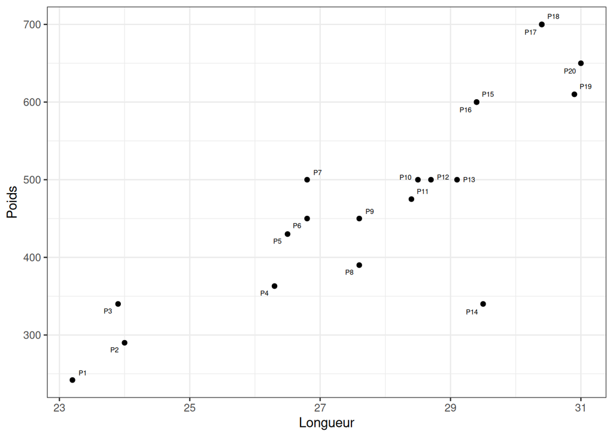

**Questions**

- Expliquer le poids des poissons en fonctions de leurs tailles ?
- Y’a-t-il une relation linéaire entre les deux ?

## 2.3 Trouver “la meilleure droite” ?

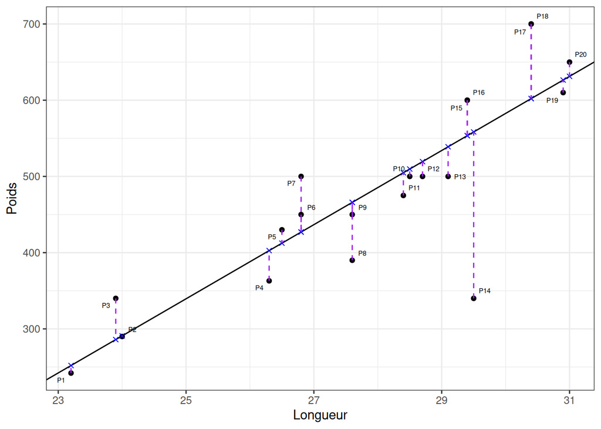

$$\begin{align}J(a,b) &=\sum_{i=1}^n e_i ^2\\
&=\sum_{i=1}^n (y_i - \widehat{y_i})^2\\
&= \sum_{i=1}^n (y_i - (ax_i + b))^2
\end{align}$$

## 2.4 Méthode des moindres carrés

**NoteDéfinition**

- Équation de la droite des moindres carrés :

$$\widehat{y}_i = ax_i+b$$

- $a$ et $b$ sont obtenus en minimisant la somme des carrés des erreurs :

$$J(a,b)=\sum_{i=1}^{n} \left(y_i-(ax_i+b)\right)^2$$

## 2.5 Droite des moindres carrés et erreurs

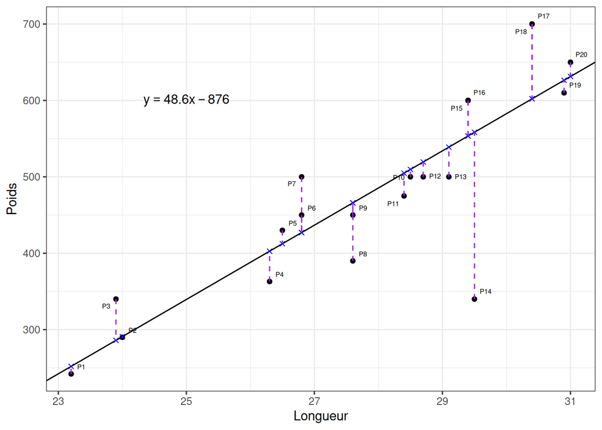

$$J(a,b)=91435.22$$

**WarningObjectif**

Avec notre échantillon de $n$ observations, quelle confiance donner à l’estimation des coefficients $a$ et $b$ ?

## 2.6 Ce qu’il faut retenir de ce cours

**NoteModélisation probabiliste du modèle linéaire**

$y_i$ est la réalisation d’une variable aléatoire $Y_i$ telle que pour $1 \leq i \leq n$:
$$Y_i = \alpha x_i + \beta + E_i, \quad E_i\overset{i.i.d.}\sim{\cal N}(0,\sigma^2)$$

**TipEstimateurs du modèle**

$${A}=\frac{\sum_{i=1}^n(x_i-\bar{x})(Y_i-\bar{Y})}{\sum_{i=1}^n(x_i-\bar{x})^2}$$
$${B}=\bar{Y}-A\bar{x}$$
$$S^2=\frac{1}{n-2}\sum_{i=1}^n(Y_i-\widehat{Y_i})^2$$

**TipValider les hypothèses du modèle avec les 4 graphes de diagnostic**

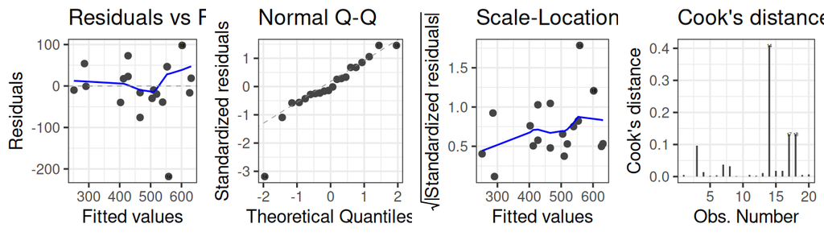

# 3 Modèle linéaire simple : théorie

## 3.1 Données

On a $n = 20$ observations.

Pour $1 \leq i \leq n$:

- $x_i$ : longueur du poisson $i$.
- $y_i$ : poids du poisson $i$.

```r
fish <- read.table(file = "fish_linsimple.csv",
                   sep =";", header = TRUE)
kable(fish[1:5,])
```

| Poids | Longueur |
| --- | --- |
| 242 | 23.2 |
| 290 | 24.0 |
| 340 | 23.9 |
| 363 | 26.3 |
| 430 | 26.5 |

```r
summary(fish)
```

```
     Poids          Longueur
 Min.   :242.0   Min.   :23.20
 1st Qu.:383.2   1st Qu.:26.73
 Median :487.5   Median :28.45
 Mean   :481.5   Mean   :27.92
 3rd Qu.:600.0   3rd Qu.:29.43
 Max.   :700.0   Max.   :31.00
```

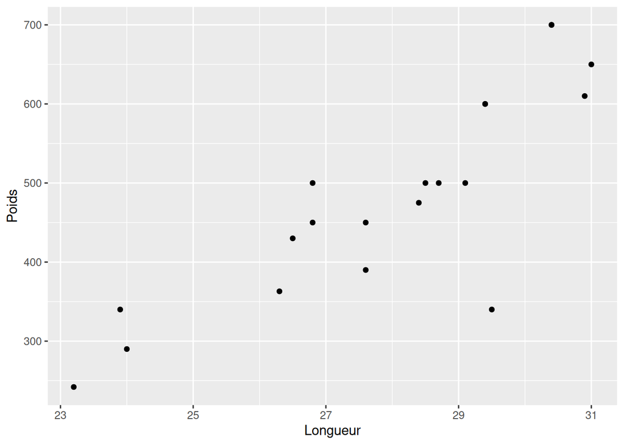

```r
ggplot(fish, aes(x = Longueur, y = Poids)) +
  geom_point()
```

## 3.2 Écriture du modèle

#### 3.2.0.1 Notations

On a $n=20$ observations. On note, pour $1 \leq i \leq n$

- $x_i$ la mesure de la longueur du poisson $i$.
- $y_i$ la mesure du poids du poisson $i$.

**NoteDéfinition : Modèle de régression linéaire simple**

On suppose que $y_i$ est la réalisation d’une variable aléatoire $Y_i$ telle que pour $1 \leq i \leq n$:
$$Y_i = \alpha x_i + \beta + E_i$$
où

- $\alpha$ est un paramètre inconnu;
- $\beta$ est un paramètre inconnu;
- $E_i$ une variable aléatoire appelée **erreur résiduelle**.

Dans notre exemple, $\alpha$ est l’effet de la longueur sur le poids.

## 3.3 Modélisation de l’erreur résiduelle

**NoteDéfinition : Modèle de régression linéaire simple**

$E_i$ une variable aléatoire appelée **erreur résiduelle** , telle que:

- Toutes les variables aléatoires $E_1,\dots, E_n$ sont **indépendantes**;
- Tous les $E_i$ ont la **même espérance**, égale à **0**;
- Tous les $E_i$ ont la **même variance**, égale à $\mathbf{\sigma^2}$ (paramètre inconnu);
- Tous les $E_i$ suivent une **loi normale**;

$\Rightarrow$ les $E_i$ sont indépendants et identiquement distribués de loi $\mathcal{N}(0, \sigma^2)$

- On notera directement $E_i\overset{i.i.d.}\sim{\cal N}(0,\sigma^2)$

## 3.4 Aléatoire ou pas ?

**CautionRemarques**

$$\color{red}{Y_i} = {\color{blue}{\underbrace{\alpha x_i + \beta}_{{déterministe}{}}}} + \color{red}{\overbrace{E_i}^{aléatoire}}\color{black}, 1 \leq i \leq n$$

où

- $\color{red}{Y_i}$ réponse **aléatoire** pour l’unité $i$
- $\color{blue}{x_i}$ valeur **non-aléatoire** de $x$ pour l’unité $i$
- $\color{blue}\alpha$ est un paramètre inconnu, l’effet de la longueur sur le poids;
- $\color{blue}\beta$ est un paramètre inconnu;
- $\color{red}{E_i}$ une variable aléatoire appelée **erreur résiduelle** les $\color{red}{E_i}$ sont indépendants et identiquement distribués de loi $\mathcal{N}(0, \sigma^2)$

## 3.5 Autre formulation du modèle linéaire

**CautionRemarques**

Le modèle

$$Y_i = \alpha x_i + \beta + E_i,\quad 1 \leq i \leq n,$$

$$\text{avec } E_i\overset{i.i.d.}\sim \mathcal{N}(0,\sigma^2)$$

est équivalent à

Les $Y_i$ sont **indépendants** et

$$Y_i \sim \mathcal{N}( \alpha x_i +\beta, \sigma^2 ), \; 1 \leq i \leq n$$

- $\mathbb{E}[Y_i]=$ $\alpha x_i + \beta$ , $\mathbb{V}[Y_i]=$ $\sigma^2$
- $x$ n’influe que sur la moyenne et pas sur la variance de $Y$
- $Y_i$ se décompose en
  - Une partie fixe expliquée par le modèle:
  - Une partie aléatoire non expliquée par le modèle

## 3.6 Exemple de modélisation linéaire simple

On a $n=20$ observations. On note, pour $1 \leq i \leq n$

- $x_i$ la mesure de la longueur du poisson $i$.
- $y_i$ la mesure du poids du poisson $i$.

On suppose que $y_i$ est la réalisation d’une v. a. $Y_i$ telle que pour $1 \leq i \leq n$:
$$Y_i = \alpha x_i + \beta + E_i \quad \text{avec} \quad E_i\overset{i.i.d.}\sim{\cal N}(0,\sigma^2)$$

# 4 Estimateurs et estimations des paramètres

## 4.1 Rappel : covariance et corrélation

**NoteRappel**

$$\bar{x} = \frac{1}{n}\sum_{i=1}^{n} x_i\quad, \quad \bar{y}\ =\ \frac{1}{n}\sum_{i=1}^{n} y_i$$
$$\mathbb{V}_{emp}(x) = \frac{1}{n}\sum_{i=1}^{n}(x_i-\bar{x})^2\quad \text{ (estimateur biaisé)}$$

$$Cov_{emp}(x,y)= \frac{1}{n}\sum_{i=1}^{n}(x_i-\bar{x})(y_i-\bar{y})$$
$$\begin{align}
r(x,y) &= \frac{\displaystyle\sum_{i=1}^n(x_i-\bar{x})(y_i-\bar{y})}{\sqrt{\displaystyle\sum_{i=1}^n(x_i-\bar{x})^2}\sqrt{\displaystyle \sum_{i=1}^n(y_i-\bar{y})^2}} \\
& = \frac{Cov_{emp}(x,y)}{\sqrt{\mathbb{V}_{emp}(x)}\sqrt{\mathbb{V}_{emp}(y)}}
\end{align}$$

## 4.2 Questions

**NoteRappel**

- Quelle est la moyenne empirique de $x$ ? de $y$ ?
- Quelle est la valeur du coefficient de correlation ? -2, -0.5 , 0, 0.3 , 0.8 ou 5 ?

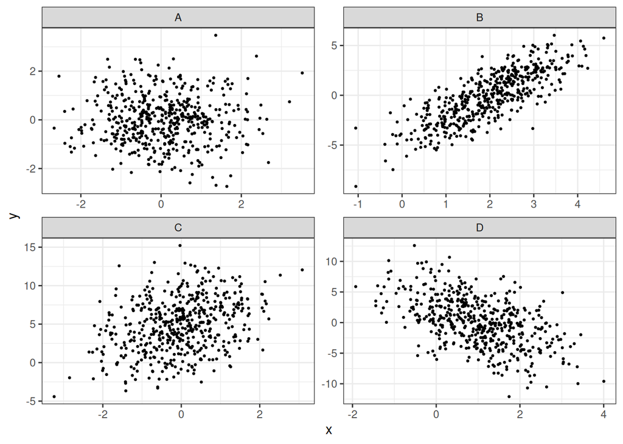

## 4.3 Questions

**NoteRappel**

- Quelle est la valeur du coefficients de correlation de $X$ avec $X$ ?
- Quelle est la valeur du coefficients de correlation de $X$ avec $2X$ ?
- Quelle est la valeur du coefficients de correlation de $X$ avec $2X + 3$ ?
- Quelle est la valeur du coefficients de correlation de $X$ avec $-X$ ?

## 4.4 Méthode des moindres carrés

**NoteDéfinition**

- Équation de la droite des moindres carrés :

$$\widehat{y}_i = ax_i+b$$

- $a$ et $b$ obtenus en minimisant la somme des carrés des erreurs

$$J(a,b)=\sum_{i=1}^{n} \left(y_i-(ax_i+b)\right)^2$$

**TipThéorème**

- La minimisation de $J(a,b)$ en $a$ et $b$ conduit à

**Exercice :**

$a =$ $\frac{\displaystyle\sum_{i=1}^n(x_i-\bar{x})(y_i-\bar{y})}{\displaystyle\sum_{i=1}^n(x_i-\bar{x})^2}= \frac{Cov_{emp}(x,y)}{\mathbb{V}_{emp}(x)}$ et

$b$ = $\bar{y} - a\bar{x}$

## 4.5 Estimateurs des paramètres du modèle :

**NoteDéfinition**

- A et B estimateurs de $\alpha$ et $\beta$ obtenus par la méthode des moindres carré.

$$\begin{align}
\color{red}{A}&=\frac{\sum_{i=1}^n(x_i-\bar{x})(Y_i-\bar{Y})}{\sum_{i=1}^n(x_i-\bar{x})^2}\\ \color{red}{A}&=\frac{\sum_{i=1}^n(x_iY_i)-n\bar{x}\bar{Y}}{\sum_{i=1}^n x_i^2-n(\bar{x})^2}\\
\color{red}{B}&=\bar{Y}-A\bar{x}
\end{align}$$

- $a$ et $b$ estimations de $\alpha$ et $\beta$ : réalisations $a$ et $b$ des estimateurs $A$ et $B$ sur les données

$$\begin{align}
\color{blue}{a}&=\frac{\sum_{i=1}^n(x_i-\bar{x})(y_i-\bar{y})}{\sum_{i=1}^n(x_i-\bar{x})^2}\\ \color{blue}{a}&=\frac{\sum_{i=1}^n(x_iy_i)-n\bar{x}\bar{y}}{\sum_{i=1}^n x_i^2-n(\bar{x})^2}\\
\color{blue}{b}&=\bar{y}-a\bar{x}
\end{align}$$

- $a$ et $b$ sont les coefficients de la droite des moindres carrés.

## 4.6 Modèle linéaire avec R

```r
modele_reg_simple <- lm(Poids~ Longueur, data = fish)
coef(modele_reg_simple)
```

```
(Intercept)    Longueur
 -876.48191    48.63832
```

$a =$ 48.6383206 et $b =$ -876.4819101

## 4.7 Estimateur de la variance des résidus

**NoteDéfinition**

- $\widehat{Y_i}=Ax_i+B$, la prévision (aléatoire) par le modèle de régression linéaire associée à $x_i$.
- $S^2$ **estimateur** de $\sigma^2$ : variance empirique
  $$\color{red}{\begin{align}S^2&=\frac{1}{n-2}\sum_{i=1}^n(Y_i-\widehat{Y_i})^2\\&=\frac{1}{n-2}\sum_{i=1}^n(Y_i-Ax_i-B)^2\end{align}}$$
- Estimation de $\sigma^2$ : réalisation $s^2$ de $S^2$ sur les données
  $$\color{blue}{\begin{align}s^2&=\frac{1}{n-2}\sum_{i=1}^n(y_i-ax_i-b)^2\\ &=\frac{1}{n-2}\sum_{i=1}^n \widehat{e}_i^2\end{align}}$$
  où $\widehat{e}_i = y_i - ax_i -b$ sont les résidus observés.

## 4.8 Modélisation des données avec R

```r
summary(modele_reg_simple)
```

```
Call:
lm(formula = Poids ~ Longueur, data = fish)

Residuals:
     Min       1Q   Median       3Q      Max
-218.349  -22.040   -5.274   46.515   97.877

Coefficients:
            Estimate Std. Error t value Pr(>|t|)
(Intercept) -876.482    198.380  -4.418 0.000332 ***
Longueur      48.638      7.082   6.868    2e-06 ***
---
Signif. codes:  0 '***' 0.001 '**' 0.01 '*' 0.05 '.' 0.1 ' ' 1

Residual standard error: 71.27 on 18 degrees of freedom
Multiple R-squared:  0.7238,    Adjusted R-squared:  0.7084
F-statistic: 47.16 on 1 and 18 DF,  p-value: 2.004e-06
```

## 4.9 Résidus observés

```r
summary(modele_reg_simple)$residuals %>% head()
```

```
          1           2           3           4           5           6
 -9.9271269  -0.8377834  54.0260487 -39.7059207  17.5664152  22.9749190
```

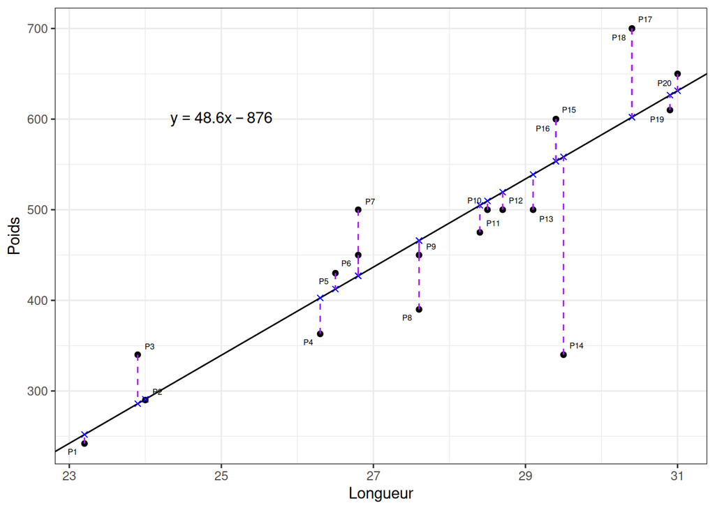

## 4.10 Fonction summary

On peut récupérer les infos:

```r
Coef <- summary(modele_reg_simple)$coefficients
class(Coef)
```

```
[1] "matrix" "array"
```

```r
Coef
```

```
              Estimate Std. Error   t value     Pr(>|t|)
(Intercept) -876.48191 198.379689 -4.418204 3.318341e-04
Longueur      48.63832   7.082325  6.867565 2.004153e-06
```

```r
names(summary(modele_reg_simple))
```

```
 [1] "call"          "terms"         "residuals"     "coefficients"
 [5] "aliased"       "sigma"         "df"            "r.squared"
 [9] "adj.r.squared" "fstatistic"    "cov.unscaled"
```

```r
summary(modele_reg_simple)$sigma
```

```
[1] 71.27226
```

# 5 Validité des hypothèses

## 5.1 **Validité des hypothèses**

Les résidus observés permettent de valider les hypothèses du modèle linéaire:

- $E_i$ une variable aléatoire appelée **résidu**, telle que:
  - Toutes les variables aléatoires $E_1,\dots, E_n$ sont **indépendantes**;
  - Tous les $E_i$ ont la **même espérance**, égale à **0**;
  - Tous les $E_i$ ont la **même variance**, égale à $\mathbf{\sigma^2}$ (paramètre inconnu);
  - Tous les $E_i$ suivent une **loi normale**;

### 5.1.1 Validation des hypothèses

- **Hypothèse d’indépendance:** Elle doit être validée par le plan d’expérience !
- **Distribution identique, de loi normale:** Ces hypothèses doivent être vérifiées grâce aux $\widehat{e}_i = y_i - \widehat{y_i}$.
- **En pratique:** diagnostic graphique des résidus

## 5.2 4 graphes de diagnostic

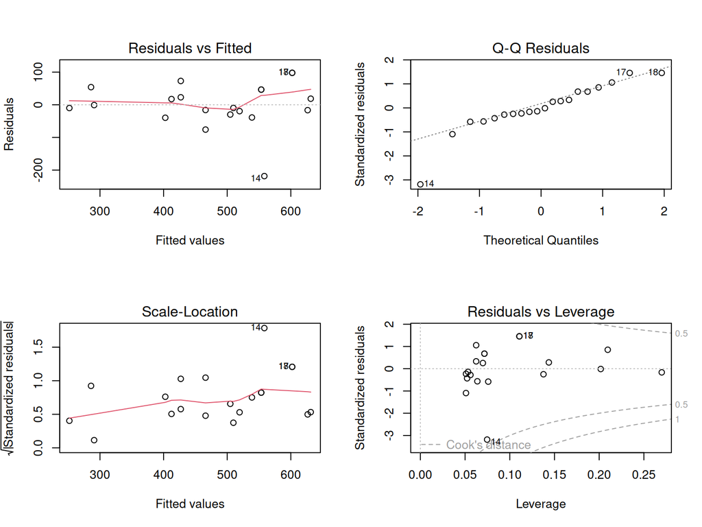

```r
par(mfrow = c(2,2))
plot(modele_reg_simple)
```

## 5.3 Distribution identique, espérance constante et nulle

**Ce qu’on regarde:** Les résidus observés $\widehat{e}_i$ en fonction des prédictions $\widehat{y}_i$.

✅

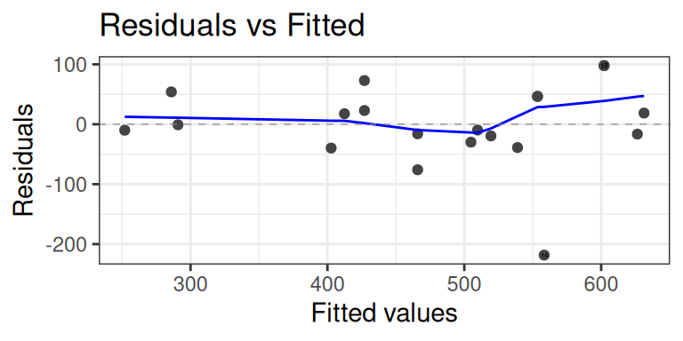

**Ce qu’on voit:** La valeur des résidus ne semble pas dépendre de la valeur des prédictions (il ne sont donc pas structurés en fonction de la prédiction). Ils sont globalement identiquement distribués autour de 0.

**Ce qu’on conclut:** On valide l’hypothèse d’espérance constante et égale à 0.

❌

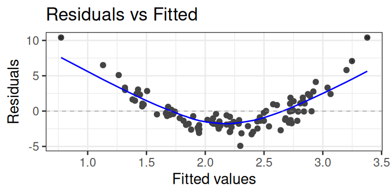

**Ce qu’on voit:** Les valeurs des résidus dépendent de la valeur des prédictions (il sont donc structurés en fonction de la prédiction).

**Ce qu’on conclut:** On ne valide pas l’hypothèse d’espérance constante et égale à 0.

## 5.4 Distribution identique, variance constante

**Ce qu’on regarde:** la racine carrée de la valeur absolue des résidus (standardisés) observés en fonction des prédictions $\widehat{y}_k$.

✅

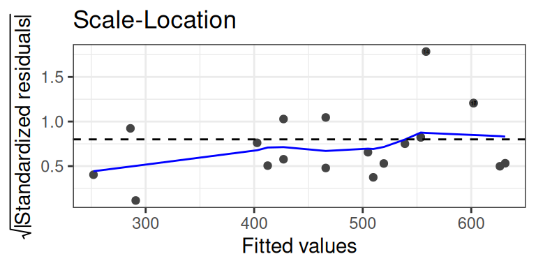

**Ce qu’on voit:** la racine carrée de la valeur absolue des résidus ne semble pas dépendre de la valeur des prédictions (il ne sont donc pas structurés en fonction de la prédiction). Ils sont globalement identiquement distribués autour de 0.8.

**Ce qu’on conclut:** On valide l’hypothèse de variance constante.

❌

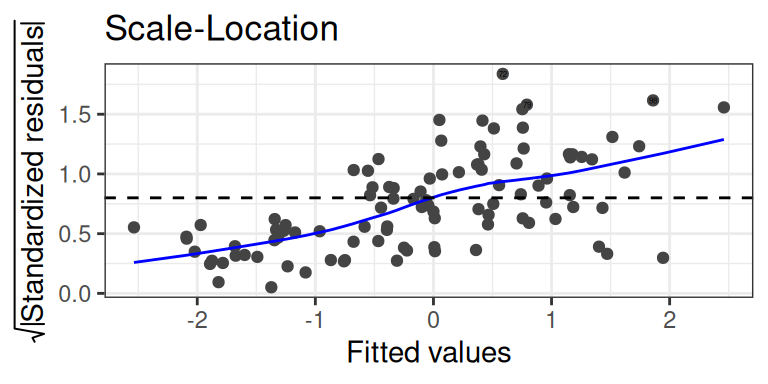

**Ce qu’on voit:** la racine carrée de la valeur absolue des résidus dépend de la valeur des prédictions (il sont donc structurés en fonction de la prédiction).

**Ce qu’on conclut:** On ne valide pas l’hypothèse de variance constante.

## 5.5 Distribution normale

**Ce qu’on regarde:** La valeur des quantiles empiriques des résidus standardisés en fonction de la valeur quantiles théoriques d’une loi normale $\mathcal{N}(0 ,1)$.

✅

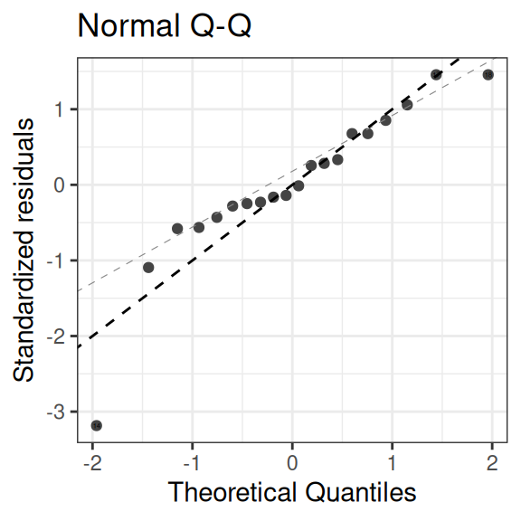

**Ce qu’on voit:** Les points sont globalement alignés sur la droite $y = x$. Les quantiles empiriques sont donc à peu près égaux aux quantiles théoriques (si les hypothèses du modèle sont vraies).

**Ce qu’on conclut:** On valide l’hypothèse de distribution normale des résidus.

❌

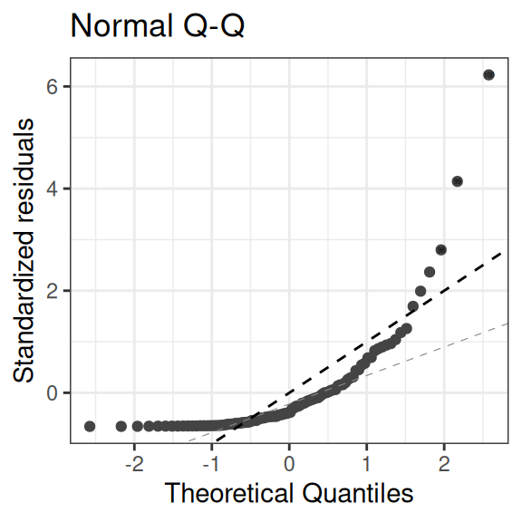

**Ce qu’on voit:** Les points ne sont pas globalement alignés sur la droite $y = x$. Les quantiles empiriques sont donc différents des quantiles théoriques.

**Ce qu’on conclut:** On ne valide pas l’hypothèse de distribution normale des résidus.

## 5.6 Points influents ou aberrants

**Ce qu’on regarde:** La valeur des résidus (standardisés) en fonction du levier de l’observation (poids d’une observation dans l’estimation de sa prédiction).

✅

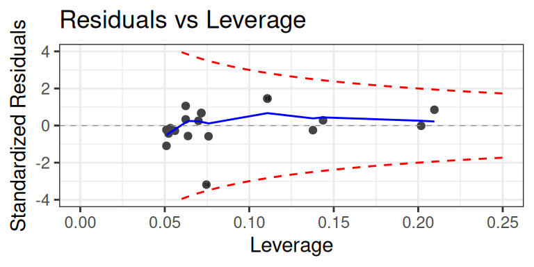

**Ce qu’on voit:** Les points ont tous un petit levier, donc aucun point n’influe trop sur la droite. Aucun point n’est en dehors de l’enveloppe délimitée par les hyperboles rouges, représentant les lignes de niveau 0.5 de la distance de Cook.

**Ce qu’on conclut:** Aucun point n’est aberrant ou trop influent.

❌

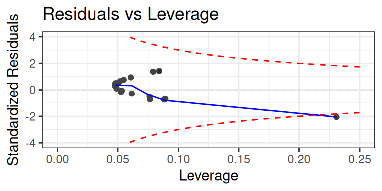

**Ce qu’on voit:** Un point est en dehors de l’enveloppe délimitée par les hyperboles rouges, représentant les lignes de niveau 0.5 de la distance de Cook.

**Ce qu’on conclut:** Il y a un point aberrant dans les données.

## 5.7 4 graphes

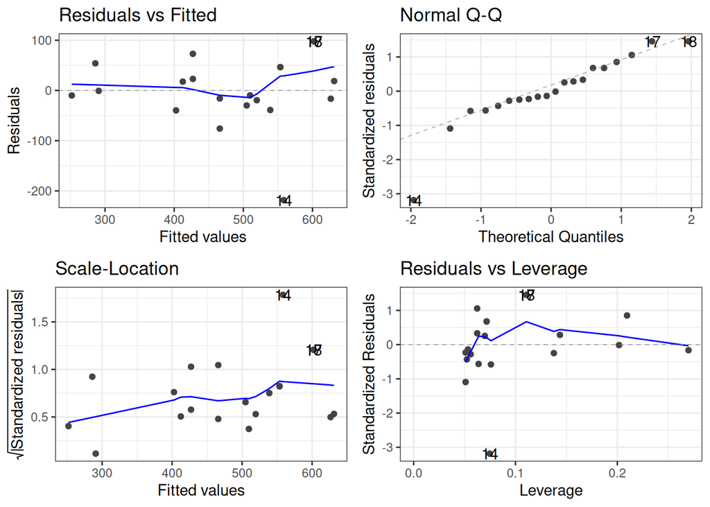

Donc on valide les hypothèses du modèle pour notre exemple.

## 5.8 Ce qu’il faut retenir de ce cours

**NoteModélisation probabiliste du modèle linéaire**

$y_i$ est la réalisation d’une variable aléatoire $Y_i$ telle que pour $1 \leq i \leq n$:
$$Y_i = \alpha x_i + \beta + E_i, \quad E_i\overset{i.i.d.}\sim{\cal N}(0,\sigma^2)$$

**TipEstimateurs du modèle**

$${A}=\frac{\sum_{i=1}^n(x_i-\bar{x})(Y_i-\bar{Y})}{\sum_{i=1}^n(x_i-\bar{x})^2}$$
$${B}=\bar{Y}-A\bar{x}$$
$$S^2=\frac{1}{n-2}\sum_{i=1}^n(Y_i-\widehat{Y_i})^2$$

**TipValider les hypothèses du modèle avec les 4 graphes de diagnostic**

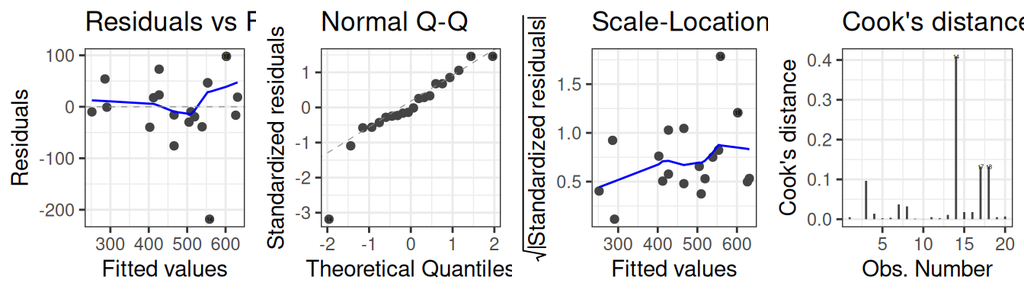

# 6 Tests de linéarité

## 6.1 Ce qu’il faut retenir de ce cours 1/3

**TipLois des estimateurs**

$$\frac{(A-\alpha)}{S_A}\sim \mathcal{T}{(n-2)}$$

$$\frac{(B-\beta)}{S_B}\sim \mathcal{T}{(n-2)}$$

**TipEstimateurs du modèle**

$$\begin{align}
IC_{1-\delta}(\alpha) =& \left[a-t_{1-\frac{\delta}{2}} s_A;a+t_{1-\frac{\delta}{2}} s_A\right]\\
IC_{1-\delta}(\beta)=&\left[b-t_{1-\frac{\delta}{2}} s_B;b+t_{1-\frac{\delta}{2}} s_B\right]\\
\end{align}$$

$s_A = \sqrt{\frac{s^2}{\sum_{i=1}^n(x_i-\bar{x})^2}}$ et $s_B = \sqrt{s^2\left(\frac{1}{n}+\frac{\bar{x}^2}{\sum_{i=1}^n(x_i-\bar{x})^2}\right)}$

**NoteTest de Student de la nullité de la pente de régression**

$$H_0:\alpha=0$$

$$H_1:\alpha\neq 0$$

**NoteTest de Fisher de Comparaison de modèles**

$$H_0\; :\; \text{modèle}\; M_1:Y_i=\beta+E_i$$

$$H_1\; :\; \text{modèle}\; M_2:Y_i=\alpha x_i+\beta+E_i$$

## 6.2 Ce qu’il faut retenir de ce cours 2/3

**NoteDéfinition : SCT**

La variabilité de $Y$ **sans tenir compte du modèle**.

$$\color{purple}{SCT =\displaystyle\sum_{i = 1}^n( Y_i - \bar{Y})^2}$$

**NoteDéfinition : SCM**

Partie de la variabilité de $Y$ **expliquée par le modèle**.

$$\color{blue}{SCM = \displaystyle\sum_{i=1}^n(\widehat{Y_i}-\bar{Y})^2}$$

**NoteDéfinition : SCR**

Partie de la variabilité de $Y$ qui n’est **pas expliquée par le modèle**.

$$\color{red}{SCR = \displaystyle\sum_{i=1}^n(Y_i-\widehat{Y_i})^2=\displaystyle\sum_{i=1}^n E_i ^2}$$

**TipDécomposition de la variance**

$$\color{purple}{SCT} = \color{blue}{SCM} + \color{red}{SCR}$$

**TipTest de Fisher**

$$T_n=\frac{SCM/1}{SCR/(n-2)} \overset{H_0}{\sim} \mathcal{F}(1,n-2)$$

## 6.3 Ce qu’il faut retenir de ce cours 3/3

**NoteCoefficient de détermination**

$$R^2 = \frac{SCM}{SCT}$$

**TipIntervalle de confiance de la droite de régression**

$$IC_{1-\delta}(\mathbb{E}[Y_0])=$$
$$\begin{align}
&\left[\widehat{y_0}-t_{1-\frac{\delta}{2}}\sqrt{s^2\left(\frac{1}{n}+\frac{(x_0-\bar{x})^2}{\sum_{i=1}^n(x_i-\bar{x})^2}\right)};\right.\\
&\left.\widehat{y_0}+t_{1-\frac{\delta}{2}}\sqrt{s^2\left(\frac{1}{n}+\frac{(x_0-\bar{x})^2}{\sum_{i=1}^n(x_i-\bar{x})^2}\right)}\right]
\end{align}$$

**TipIntervalle de prévision**

$$IP_{1-\delta}(Y_0)=$$

$$\begin{align}
&\left[\widehat{y_0}-t_{1-\frac{\delta}{2}}\sqrt{s^2\left(1+\frac{1}{n}+\frac{(x_0-\bar{x})^2}{\sum_{i=1}^n(x_i-\bar{x})^2}\right)};\right.\\
&\left.\widehat{y_0}+t_{1-\frac{\delta}{2}}\sqrt{s^2\left(1+\frac{1}{n}+\frac{(x_0-\bar{x})^2}{\sum_{i=1}^n(x_i-\bar{x})^2}\right)}\right]
\end{align}$$

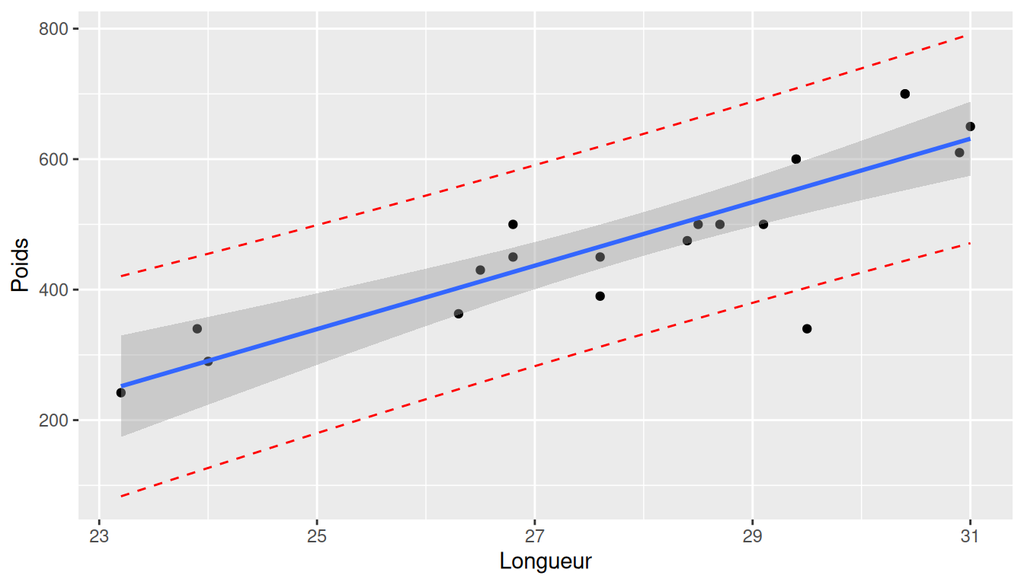

## 6.4 Degrés de libertés (Degrees of freedom)

**NoteDéfinition**

**Degrés de libertés (Degrees of freedom)** : Le nombre d’observations moins le nombre de paramètres d’espérance à estimer.

- Dans le cadre du modèle linéaire simple le nombre de paramètre d’espérance à estimer est 2.
- On a $n$ observations le nombre de degrées de libertés est donc : $n-2$

## 6.5 Propriété et loi de l’estimateur $S^2$:

**TipThéorème**

$S^2$ est un estimateur sans biais de $\sigma^2$ et on a

$$\frac{(n-2)S^2}{\sigma^2}=\frac{\sum_{i=1}^n(Y_i-Ax_i-B)^2}{\sigma^2}$$

$$\frac{(n-2)S^2}{\sigma^2}\sim\chi^2(n-2)$$
De plus $S^2$ est **indépendant** de $A$, $B$ et $\bar{Y}$

## 6.6 Propriétés et loi des estimateurs $A$ et $B$

**TipThéorème**

$A$ et $B$ sont des estimateurs sans biais et consistants de $\alpha$ et $\beta$. $A$ et $B$ suivent des lois normales d’espérance $\alpha$ et $\beta$, et de variance

$$\begin{align}
Var(A)&=\frac{\sigma^2}{\sum_{i=1}^n(x_i-\bar{x})^2}\\
& \\
Var(B)&=\sigma^2\left(\frac{1}{n}+\frac{\bar{x}^2}{\sum_{i=1}^n(x_i-\bar{x})^2}\right)
\end{align}$$
Si on remplace $\sigma^2$ par $S^2$ pour obtenir des estimateurs des variances

$$S^2_A=\frac{S^2}{\sum_{i=1}^n(x_i-\bar{x})^2}$$

$$S^2_B=S^2\left(\frac{1}{n}+\frac{\bar{x}^2}{\sum_{i=1}^n(x_i-\bar{x})^2}\right)$$

on a

$$\frac{(A-\alpha)}{S_A}\sim \mathcal{T}{(n-2)}$$

$$\frac{(B-\beta)}{S_B}\sim \mathcal{T}{(n-2)}$$

## 6.7 Intervalle de confiance aléatoire de $\alpha$ et $\beta$

**TipThéorème**

A partir des lois de $A$ et $B$, on obtient:

Intervalles de confiance aléatoire des estimateurs de niveau $1-\delta$ de $\alpha$ et $\beta$

$$\begin{align}
IC_{1-\delta}(\alpha) = \left[A-t_{1-\frac{\delta}{2}} S_A;A+t_{1-\frac{\delta}{2}} S_A\right]\\
IC_{1-\delta}(\beta)=\left[B-t_{1-\frac{\delta}{2}} S_B;B+t_{1-\frac{\delta}{2}} S_B\right]\\
\end{align}$$

où $t_{1-\frac{\delta}{2}}$ est tel que $\mathbb{P}\left(\mid \mathcal{T}(n-2)\mid \leq t_{1-\frac{\delta}{2}}\right)=1-\delta$

$t_{1-\frac{\delta}{2}}$ est le quantile d’ordre $1-\frac{\delta}{2}$ de la loi de $\mathcal{T}(n-2)$.

## 6.8 Intervalle de confiance de $\alpha$ et $\beta$

**TipThéorème**

- Intervalles de confiance des estimateurs de niveau $1-\delta$ de $\alpha$ et $\beta$

$$\begin{align}
IC_{1-\delta}(\alpha) = &\left[a-t_{1-\frac{\delta}{2}} s_A;a+t_{1-\frac{\delta}{2}} s_A\right]\\
IC_{1-\delta}(\beta)=&\left[b-t_{1-\frac{\delta}{2}} s_B;b+t_{1-\frac{\delta}{2}} s_B\right]\\
\end{align}$$

- où $t_{1-\frac{\delta}{2}}$ est tel que $\mathbb{P}\left(\mid \mathcal{T}(n-2)\mid \leq t_{1-\frac{\delta}{2}}\right)=1-\delta$
- $t_{1-\frac{\delta}{2}}$ est le quantile d’ordre $1-\frac{\delta}{2}$ de la loi de $\mathcal{T}(n-2)$.
- $s_A = \sqrt{\frac{s^2}{\sum_{i=1}^n(x_i-\bar{x})^2}}$ : réalisation de $S_A$
- $s_B = \sqrt{s^2\left(\frac{1}{n}+\frac{\bar{x}^2}{\sum_{i=1}^n(x_i-\bar{x})^2}\right)}$ : réalisation de $S_B$

## 6.9 Intervalle de confiance avec R

- Intervalle de confiance à 95%

```r
confint(modele_reg_simple, level = 0.95)
```

```
                  2.5 %     97.5 %
(Intercept) -1293.26217 -459.70165
Longueur       33.75891   63.51773
```

## 6.10 Test dans le modèle de régression linéaire simple gaussien

**Test du caractère significatif de la liaison linéaire**

- Test de Student de la nullité de la pente de régression $H_0:\alpha=0$ contre $H_1:\alpha\neq 0$
- Test de Fisher de Comparaison de modèles :
  $$H_0\; \text{modèle}\; M_1:Y_i=\beta+E_i$$
  $$\text{avec } E_i\overset{i.i.d}\sim {\cal N}(0,\sigma^2)$$

contre l’alternative

$$H_1\; :\; \text{modèle}\; M_2:Y_i=\alpha x_i+\beta+E_i$$

$$\text{avec } E_i\overset{i.i.d}\sim {\cal N}(0,\sigma^2)$$

## 6.11 Test de Student de la nullité de la pente de régression

**Modélisation des données** :

$(x_i,y_i)$, $i=1,\dots,n$ : modèle linéaire $\forall i=1,\cdots,n$

$$Y_i=\alpha x_i+\beta+E_i, \; E_i\overset{i.i.d.}\sim{\cal N}(0,\sigma^2)$$

**Hypothèses** :

Test de
$$H_0:\alpha=0$$

contre

$$H_1:\alpha\neq 0$$
au risque $\delta=5\%$

## 6.12 Statistique de test

$H_0:\alpha=0$ contre $H_1:\alpha\neq 0$

**Statistique de test** :

$$T_n =\frac{(A-\alpha)}{S_A} \overset{H_0}= \frac{A}{S_A} \overset{H_0}\sim \mathcal{T}{(n-2)}$$

**Zone de rejet** :

$$R_\delta = \{|T_n| > t_{1-\frac{\delta}{2}}\}$$

On rejette $H_0$ si $t_{n} \in R_{\delta}$

**Application numérique** :

On calcule $t_{n} = \frac{a}{s_A}$ la réalisation de $T_n$.

On compare avec $t_{1-\frac{\delta}{2}}$ et on conclue.

## 6.13 p-valeur du test

$p$-valeur :

$$\begin{align}p_c&=\mathbb{P}_{H_0}(\mid T_n\mid >\mid t_{obs}\mid)\\&=2(1-\mathbb{P}(T_n\leq |t_n|))\end{align}$$
où $T_n\sim \mathcal{T}(n-2)$

Pour un risque de 1ere espèce $\delta$ fixé acceptable (par ex $\delta=5\%$)

- si $p_c <\delta$, on rejette $H_0$, le test de niveau $\delta$ est significatif (liaison significative)
- si $p_c >\delta$, on ne rejette $H_0$ pas, le test de niveau $\delta$ n’est pas significatif (liaison non significative)

## 6.14 Test de student sur la pente de régression avec R

```r
summary(modele_reg_simple)$coefficient
```

```
              Estimate Std. Error   t value     Pr(>|t|)
(Intercept) -876.48191 198.379689 -4.418204 3.318341e-04
Longueur      48.63832   7.082325  6.867565 2.004153e-06
```

$T_n = \frac{a}{s_A}$

```r
48.63832 / 7.082325
```

```
[1] 6.867564
```

$\begin{align}p_c &=\mathbb{P}_{H_0}(\mid T_n\mid >\mid t_n\mid)\\&= 2(1-\mathbb{P}_{H_0}(T_n\leq |t_n|))\end{align}$ où $T_n\sim \mathcal{T}(n-2)$

```r
n <- nrow(fish)
2*(1-pt(abs(6.867564), n - 2))
```

```
[1] 2.004155e-06
```

## 6.15 Test de Fisher du caractère significatif de la linéarité

**Approche par comparaison de modèles**

- Comparer les modèles $M_1$ et $M_2$ (à un et deux paramètres d’espérance) définis par

$$\begin{align}
M_1 &: Y_i= \beta+E_i,\quad E_i\ \overset{i.i.d.}\sim\ {\cal N}(0,\sigma^2)\\
M_2 &: Y_i=\alpha x_i+\beta+E_i,\quad E_i\ \overset{i.i.d.}\sim\ {\cal N}(0,\sigma^2)
\end{align}$$

- Revient à tester, au risque $\delta$ fixé, l’hypothèse nulle

$$H_0 : \mbox{ modèle } M_1$$

contre l’alternative

$$H_1 : \mbox{ modèle } M_2$$

## 6.16 Étude de la variance

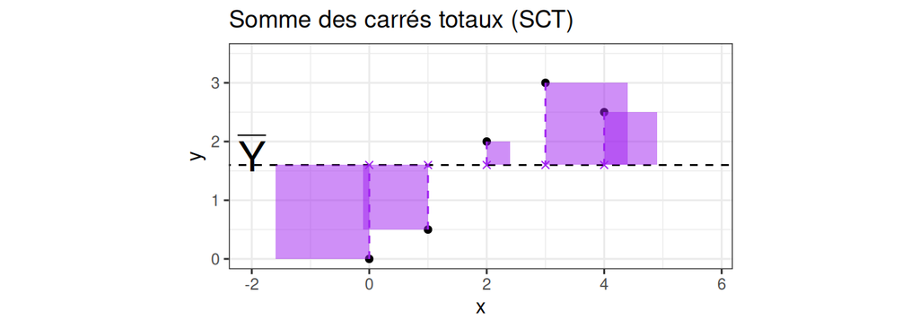

**NoteDéfinition : Somme des Carrés Totale**

La variabilité de $Y$ **sans tenir compte du modèle**.

$$\color{purple}{SCT =\displaystyle\sum_{i = 1}^n( Y_i - \bar{Y})^2}$$

## 6.17 Étude de la variance

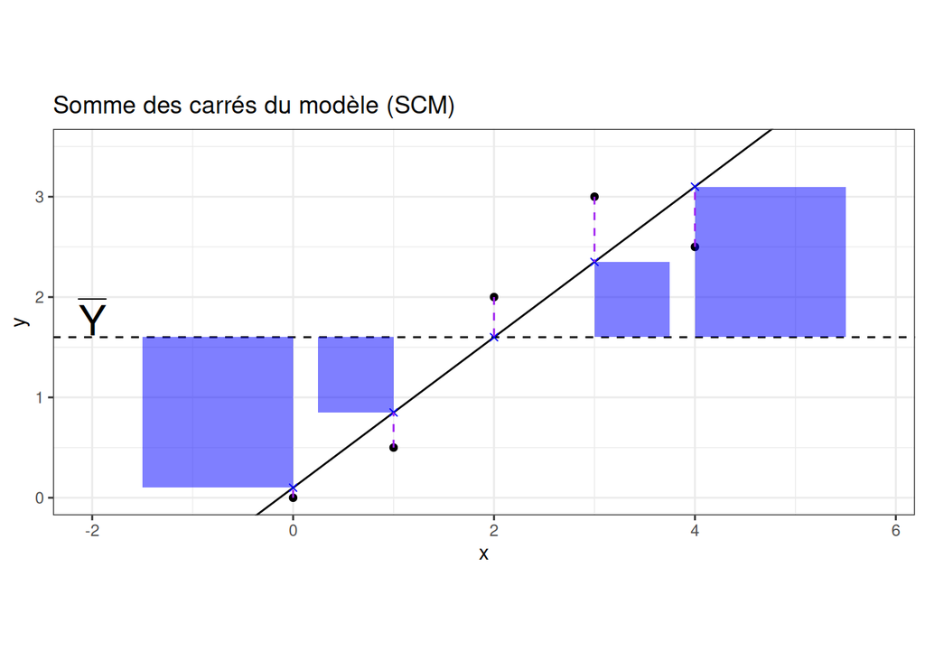

**NoteDéfinition : Somme des Carrés du Modèle**

Partie de la variabilité de $Y$ **expliquée par le modèle**.

$$\color{blue}{SCM = \displaystyle\sum_{i=1}^n(\widehat{Y_i}-\bar{Y})^2}$$

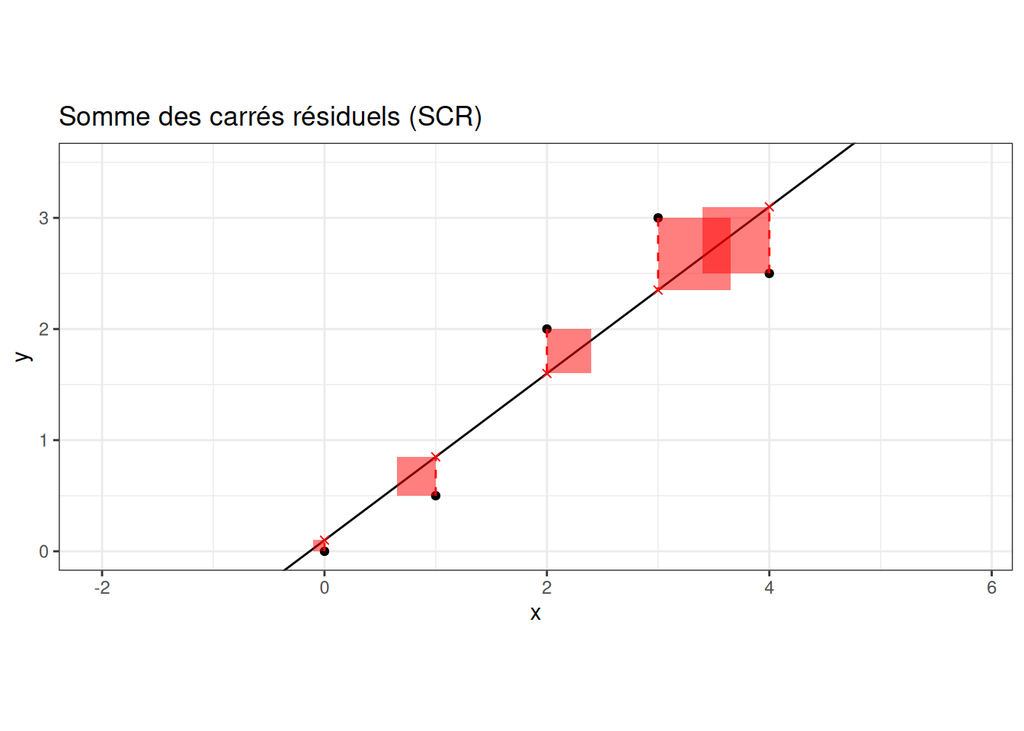

**NoteDéfinition : Somme des Carrés Résiduelles**

Partie de la variabilité de $Y$ qui n’est **pas expliquée par le modèle**.

$$\color{red}{\begin{align}SCR = \displaystyle\sum_{i=1}^n(Y_i-\widehat{Y_i})^2=\displaystyle\sum_{i=1}^n E_i ^2\end{align}}$$

## 6.18 Décomposition de la variance

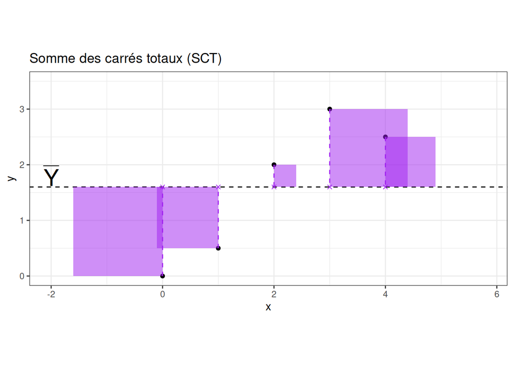

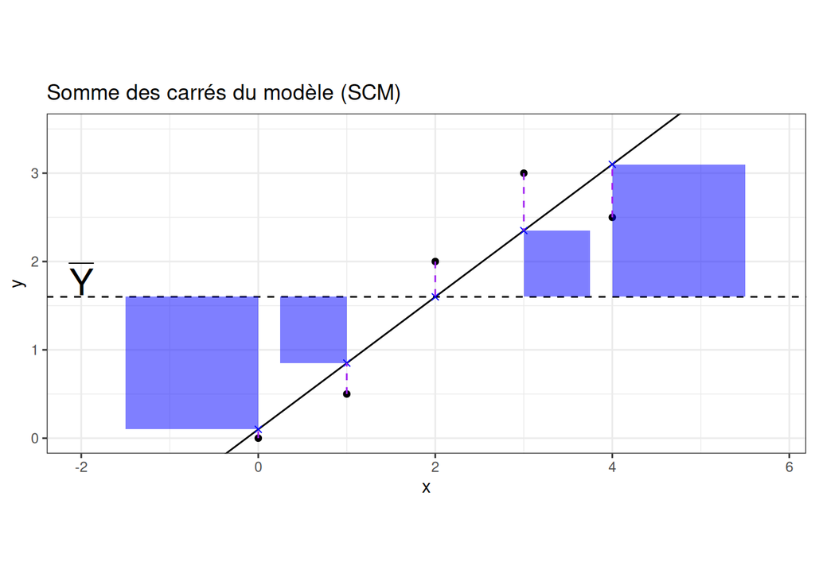

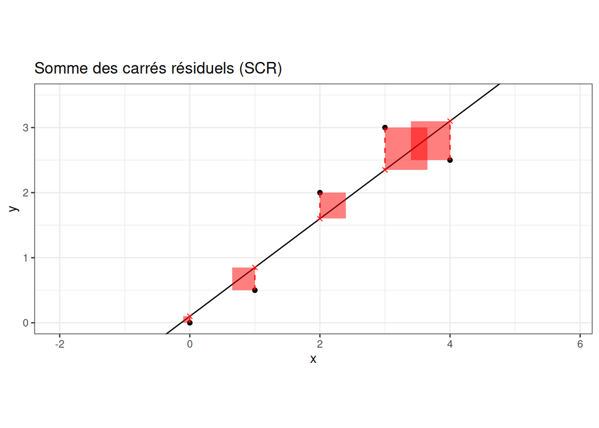

$$\color{purple}{SCT =\displaystyle\sum_{i = 1}^n( Y_i - \bar{Y})^2}$$

$$\color{blue}{SCM = \displaystyle\sum_{i=1}^n(\widehat{Y_i}-\bar{Y})^2}$$

$$\color{red}{SCR = \displaystyle\sum_{i=1}^n(Y_i-\widehat{Y_i})^2=\displaystyle\sum_{i=1}^n E_i ^2}$$

**TipThéorème**

$$\color{purple}{SCT} = \color{blue}{SCM} + \color{red}{SCR}$$

## 6.19 L’idée derrière le test

#### 6.19.0.1 Modèle avec pente significative. $SCM$ est significativement plus grande que $SCR$.

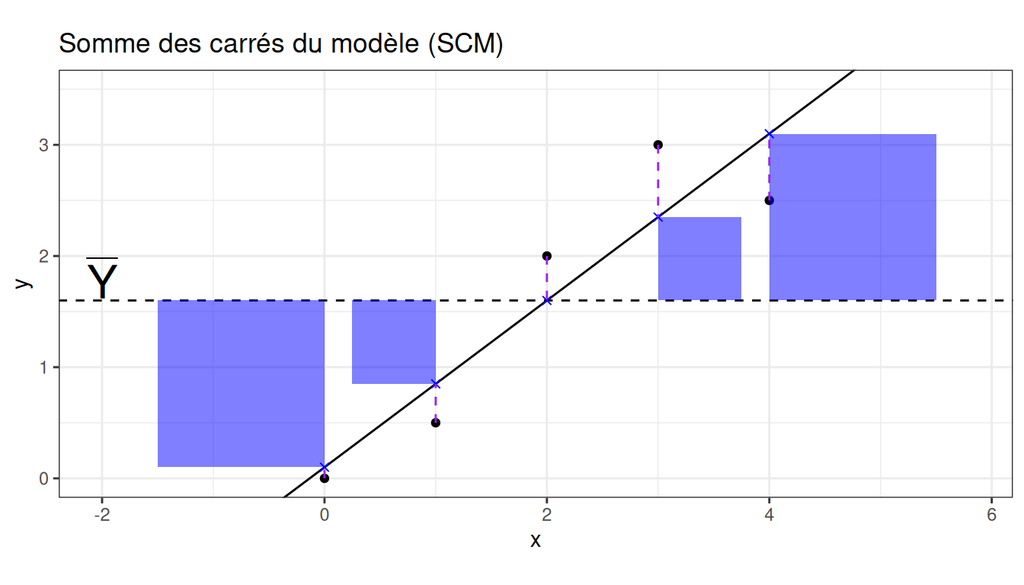

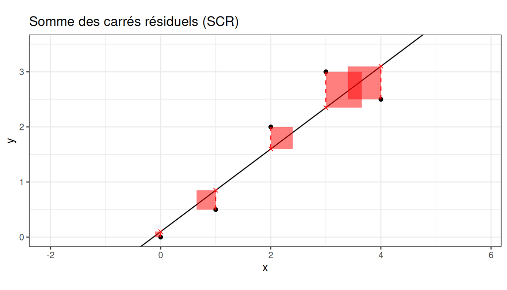

#### 6.19.0.2 Modèle sans pente significative. $SCM$ n’est pas significativement plus grande que $SCR$.

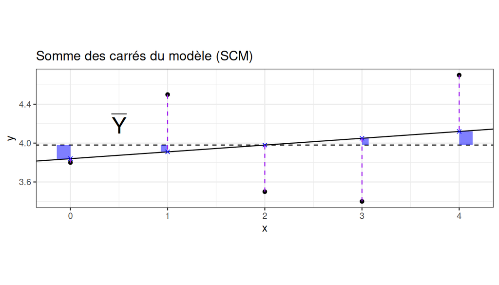

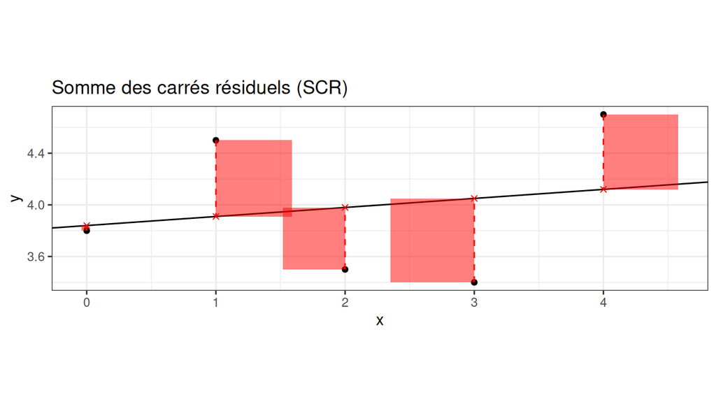

## 6.20 Test de Fisher

Il s’agit d’un test unilatéral de comparaison de variance !

**Statistique de test**

$$T_n=\frac{SCM/1}{SCR/(n-2)} \overset{H_0}{\sim} \mathcal{F}(1,n-2)$$

**Zone de rejet**

$$R_\delta = \{T_n > f_{1-\delta} \}$$

$f_{1-\delta}$ est le quantile $1 - \delta$ de la loi de Fisher $\mathcal{F}(1,n-2)$.

$\mathbb{P}_{H_0}(T_n<f_{1-\delta})=1-\delta$

**Application numérique**

- On calcule $t_n$
- On rejette $H_0$ si $t_{n} \in R_{\delta}$

**Calcul de** $p_c$

$p_{c} = \mathbb{P}_{H_0}(T_n > t_n)=1-\mathbb{P}(F<t_n)$ où $F\sim \mathcal{F}(1,n-2)$

## 6.21 Test de fisher avec R

```r
summary(modele_reg_simple)
```

```
Call:
lm(formula = Poids ~ Longueur, data = fish)

Residuals:
     Min       1Q   Median       3Q      Max
-218.349  -22.040   -5.274   46.515   97.877

Coefficients:
            Estimate Std. Error t value Pr(>|t|)
(Intercept) -876.482    198.380  -4.418 0.000332 ***
Longueur      48.638      7.082   6.868    2e-06 ***
---
Signif. codes:  0 '***' 0.001 '**' 0.01 '*' 0.05 '.' 0.1 ' ' 1

Residual standard error: 71.27 on 18 degrees of freedom
Multiple R-squared:  0.7238,    Adjusted R-squared:  0.7084
F-statistic: 47.16 on 1 and 18 DF,  p-value: 2.004e-06
```

## 6.22 Table d’analyse de la variance

$$\begin{array}{|c|c|c|c|c|c|}
\hline \text{Source} & \text{ddl} & \text{Somme} & \text{Carrés Moyens} &
\text{statistique} & p_c\\ \text{de variabilité} & \text{des Carrés} & SC & CM & \text{de test} & \\
\text{de }Y &&&&&\\
\hline \text{Modèle} & 1 & \text{SCM} & CMM=SCM/1 & t_n=\frac{CMM}{CMR} &
\mathbb{P}(\mathcal{F}(1,n-2)>t_n) \\ \text{Résidu} & n-2 & SCR & CMR=SCR/(n-2) &&\\
\hline \text{Total} & n-1 & SCT & CMT=SCT/(n-1) &&\\ \hline
\end{array}$$

```r
anova(modele_reg_simple)
```

```
Analysis of Variance Table

Response: Poids
          Df Sum Sq Mean Sq F value    Pr(>F)
Longueur   1 239578  239578  47.163 2.004e-06 ***
Residuals 18  91435    5080
---
Signif. codes:  0 '***' 0.001 '**' 0.01 '*' 0.05 '.' 0.1 ' ' 1
```

## 6.23 Une autre formulation du test de Fisher

On veut tester

- $H_0$: Modèle $M_1$ : $Y_i=\beta+E_i$ avec $E_i\overset{i.i.d}\sim{\cal N}(0,\sigma^2)$

contre

- $H_1$: Modèle $M_2$ : $Y_i=\beta+ \alpha x_i+E_i$ avec $E_i\overset{i.i.d}\sim{\cal N}(0,\sigma^2)$

Cette fois-ci, on va se concentrer sur les **résidus** de ces deux modèles.

## 6.24 Les résidus du modèle $M_2$

$$Y_i=\beta+ \alpha x_i+E_i, \mbox{ où } E_i\overset{i.i.d.}\sim{\cal N}(0,\sigma^2)$$

- $Y_i \overset{i.i.d.}\sim {\mathcal N}(\alpha x_i+\beta;\sigma^2)$.
- **2 paramètres d’espérance** $\alpha$ et $\beta$ estimés (par les moindres carrés) par $A$ et $B$.
- Prédicteur $\widehat{Y_i}(M_2)=Ax_i+B$
- Somme des carrés résiduelles :

$$\begin{align}SCR(M_2) = \sum_{i=1}^n (Y_i-\widehat{Y_i}(M_2))^2 \\= \sum_{i=1}^n (Y_i-Axi-B)^2\end{align}$$

## 6.25 Les résidus du modèle $M_1$

$$Y_i=\beta+E_i, \mbox{ où } E_i\overset{i.i.d.}\sim{\cal N}(0,\sigma^2)$$

- $Y_i\overset{i.i.d.}\sim{\cal N}(\beta;\sigma^2)$
- **1 paramètre d’espérance** $\beta$ estimé (par les moindres carrés) par $\bar{Y}$.
- Prédicteur $\widehat{Y_i}(M_1) = \bar{Y}$
- Somme des carrés résiduelles :

$$\begin{align}SCR(M_1)&=\sum_{i=1}^n E_i^2(M_1)\\&=\sum_{i=1}^n (Y_i-\widehat{Y}_i(M_1))^2\\&=\sum_{i=1}^n (Y_i-\bar{Y})^2=SCT\end{align}$$

## 6.26 Interprétation du test de Fisher

**TipThéorème**

Statistique de test $T_n$ peut s’écrire

$$\begin{align}
T_n &= \frac{SCM/ 1}{SCR(M_2)/(n-2)} \\
= &\frac{(SCR(M_{\color{red}{1}}) - SCR(M_{\color{red}{2}}))/ ( 2 - 1)}{SCR(M_2)/(n- 2)}\\&\overset{H_0}\sim \mathcal{F}(1,n-2)
\end{align}$$

**CautionRemarques**

- $SCR(M_{\color{red}{1}}) - SCR(M_{\color{red}{2}})$ : différence des variances non expliquées par les modèles.
- $(2-1)$ : différence du nombre de paramètres.
- $SCR(M_1)\geq SCR(M_2)$ (toujours !).

## 6.27 Remarque sur le test de Fisher

**CautionRemarques**

- Le test répond à la question : la droite des moindres carrés $y=ax+b$ (modèle $M_2$ estimé) explique mieux le nuage de points que la droite horizontale $y=b$ (modèle $M_1$ estimé), mais le gain est-il significatif ?
- $SCR(M_1)\geq SCR(M_2)$
- On n’abandonnera $M_1$ pour que $M_2$ que si la réduction d’erreurs en passant du “petit” modèle $M_1$ au “grand” modèle $M_2$ est significative.
- L’introduction de la pente a permis d’expliquer $SCM=SCR(M_1)-SCR(M_2)$ et a laissé inexpliquée $SCR(M_2)$.

## 6.28 Autre méthode: test de Fisher avec R

```r
mod1 <- lm(Poids~1, data = fish)

summary(mod1)
```

```
Call:
lm(formula = Poids ~ 1, data = fish)

Residuals:
    Min      1Q  Median      3Q     Max
-239.50  -98.25    6.00  118.50  218.50

Coefficients:
            Estimate Std. Error t value Pr(>|t|)
(Intercept)   481.50      29.51   16.31 1.25e-12 ***
---
Signif. codes:  0 '***' 0.001 '**' 0.01 '*' 0.05 '.' 0.1 ' ' 1

Residual standard error: 132 on 19 degrees of freedom
```

## 6.29 Autre méthode: test de Fisher avec R

```r
anova(mod1,modele_reg_simple)
```

```
Analysis of Variance Table

Model 1: Poids ~ 1
Model 2: Poids ~ Longueur
  Res.Df    RSS Df Sum of Sq      F    Pr(>F)
1     19 331013
2     18  91435  1    239578 47.163 2.004e-06 ***
---
Signif. codes:  0 '***' 0.001 '**' 0.01 '*' 0.05 '.' 0.1 ' ' 1
```

## 6.30 Lien entre les deux tests

**CautionRemarques**

- Test de Student : $T^S_{n}=\frac{A}{S_A}\overset{H_0}\sim \mathcal{T}(n-2)$
- Test de Fisher : $T^F_{n}=\displaystyle\frac{SCM/1}{SCR/(n-2)}\overset{H_0}\sim \mathcal{F}(1,n-2)$.
- procédure équivalente : $\left(T^S_{n,1}\right)^2=T^F_{n}$ et la loi du carré d’une variable aléatoire $\mathcal{T}(n-2)$ est une loi de Fisher $\mathcal{F}(1,n-2)$